# Prueba Markdown

Angel Arcones

17/1/2022

# Intro a RMarkdown

Este script es un ejemplo básico de cómo utilizar `RMarkdown`.  
La idea es mostrar algunas de las funciones que ofrece para:

- Formatear texto para documentar, usando Markdown
- Organizar código de R en celdas
- Mostrar resultados del código de forma limpia y ordenada.

## ¿Para qué usar RMarkdown?

Es muy util sobretodo para **organizar y documentar** scripts, ya que permite tener el código en bloques separados (*celdas*) que se pueden ejecutar independientemente, y permite además incluir texto con múltiples opciones de formateo.

Un ejemplo de cómo se puede visualizar un bloque de código y sus resultados:

```r
for(i in 1:5){
  print(paste0("Número ", i))
}
```

```
## [1] "Número 1"
## [1] "Número 2"
## [1] "Número 3"
## [1] "Número 4"
## [1] "Número 5"
```

**La edición de texto permite además**

Usar *cursiva*, tachado, esto llamado `verbatim`, poner<sup>indices</sup> y tambien<sub>subindices</sub>

Escribir formulas: $y = \frac{-b \pm \sqrt{b^{2}-4ac}}{2a}$

Utilizar [links a webs](https://www.mncn.csic.es/es)

## Ejemplos con código

Para comenzar, como se haría en cualquier script, lo primero es cargar las librerías necesarias. En este caso, vamos a usar el conjunto de librerias incluidas en **Tidyverse** para manejo y visualización de datos, la librería **dslabs** que contiene datasets para usar, y la librería **knitr** que permite dar un formato mas limpio a las tablas en Markdown

En este caso, en las opciones de celda se selecciona para el output `Show nothing (Run Code)`, para que lo ejecute pero no muestre los mensajes de instalación/carga de librerias en documento

### Tablas

Empezamos por cargar uno de los datasets disponibles en dslabs, en concreto el llamado *movielens*, que contiene valoraciones de peliculas de cine de las últimas décadas.

```r
data(movielens)
head(movielens)
```

|  | movieId | title | year | genres | userId | rating | timestamp |
| --- | --- | --- | --- | --- | --- | --- | --- |
| 1 | 31 | Dangerous Minds | 1995 | Drama | 1 | 2.5 | 1260759144 |
| 2 | 1029 | Dumbo | 1941 | Animation\|Children\|Drama\|Musical | 1 | 3.0 | 1260759179 |
| 3 | 1061 | Sleepers | 1996 | Thriller | 1 | 3.0 | 1260759182 |
| 4 | 1129 | Escape from New York | 1981 | Action\|Adventure\|Sci-Fi\|Thriller | 1 | 2.0 | 1260759185 |
| 5 | 1172 | Cinema Paradiso (Nuovo cinema Paradiso) | 1989 | Drama | 1 | 4.0 | 1260759205 |
| 6 | 1263 | Deer Hunter, The | 1978 | Drama\|War | 1 | 2.0 | 1260759151 |

Se pueden sacar algunos conteos de filas, columnas o nombres de las variables

```r
nrow(movielens)
ncol(movielens)
colnames(movielens)
```

```
## [1] 100004
## [1] 7
## [1] "movieId"   "title"     "year"      "genres"    "userId"    "rating"
## [7] "timestamp"
```

También se puede obtener resultados más largos, como los años para los que existen datos. En todos estos casos viene incluido por defecto los simbolos de inicio de linea al mostrar resultados, aunque existen alternativas e incluso se podría ocultar usando `comment=NA` en las opciones de la celda.

```r
sort(unique(movielens$year))
```

```
  [1] 1902 1915 1916 1917 1918 1919 1920 1921 1922 1923 1924 1925 1926 1927 1928
 [16] 1929 1930 1931 1932 1933 1934 1935 1936 1937 1938 1939 1940 1941 1942 1943
 [31] 1944 1945 1946 1947 1948 1949 1950 1951 1952 1953 1954 1955 1956 1957 1958
 [46] 1959 1960 1961 1962 1963 1964 1965 1966 1967 1968 1969 1970 1971 1972 1973
 [61] 1974 1975 1976 1977 1978 1979 1980 1981 1982 1983 1984 1985 1986 1987 1988
 [76] 1989 1990 1991 1992 1993 1994 1995 1996 1997 1998 1999 2000 2001 2002 2003
 [91] 2004 2005 2006 2007 2008 2009 2010 2011 2012 2013 2014 2015 2016
```

Aqui se hace un filtrado y agrupación para obtener una tabla con el número de películas por año desde 2008 y su nota media.

```r
df_tabla <- movielens %>% filter(year>=2008) %>%
              group_by(year) %>%
              summarise("Peliculas por año" = n(), "Nota media"=round(mean(rating),2))

df_tabla
```

| year | Peliculas por año | Nota media |
| --- | --- | --- |
| 2008 | 1544 | 3.50 |
| 2009 | 1375 | 3.52 |
| 2010 | 1238 | 3.54 |
| 2011 | 926 | 3.40 |
| 2012 | 939 | 3.40 |
| 2013 | 839 | 3.36 |
| 2014 | 798 | 3.42 |
| 2015 | 535 | 3.37 |
| 2016 | 124 | 3.22 |

El formato por defecto de la tabla anterior no es especialmente bonito ni útil a la hora de documentar. Por eso existen opciones como la funcion `kable` del paquete **knitr**, que produce unos resultados más limpios y permite un mayor control del aspecto final.

```r
kable(df_tabla, caption = "Peliculas por año y nota media\n(2008-2016)", align="ccc")
```

Peliculas por año y nota media (2008-2016)

| year | Peliculas por año | Nota media |
| --- | --- | --- |
| 2008 | 1544 | 3.50 |
| 2009 | 1375 | 3.52 |
| 2010 | 1238 | 3.54 |
| 2011 | 926 | 3.40 |
| 2012 | 939 | 3.40 |
| 2013 | 839 | 3.36 |
| 2014 | 798 | 3.42 |
| 2015 | 535 | 3.37 |
| 2016 | 124 | 3.22 |

Esto se puede emplear también para visualizar tablas de resultados de análisis estadísticos, como en este caso una regresion lineal.

```r
regresion <- lm(year~rating, data=movielens)
resultados <- coef(summary(regresion))
kable(resultados, caption="Regresión entre año y valoración", align = "cccc", digits = 2)
```

Regresión entre año y valoración

|  | Estimate | Std. Error | t value | Pr(>\|t\|) |
| --- | --- | --- | --- | --- |
| (Intercept) | 1997.88 | 0.17 | 12066.16 | 0 |
| rating | -1.71 | 0.04 | -38.17 | 0 |

Se pueden encontrar mas opciones a utilizar con kable [aquí](https://bookdown.org/yihui/rmarkdown-cookbook/kable.html).

### Gráficos

Markdown tambien permite tener en el script y el documento de texto los resultados graficos que normalmente estarian en la ventana del visor de R.  
Este primer ejemplo es utilizando las funciones de ploteo de R base

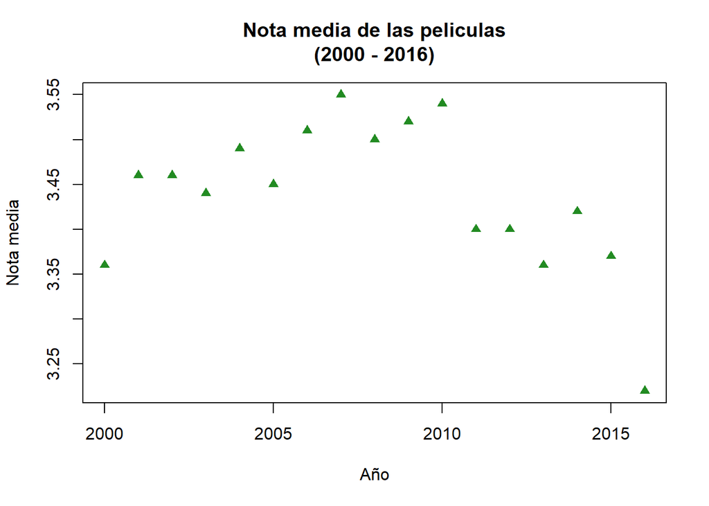

```r
df_plot <- movielens %>% filter(year>=2000) %>%
              group_by(year) %>%
              summarise("Peliculas" = n(),
                        "Nota_media"=round(mean(rating),2)) %>% as.data.frame()

plot(df_plot$year, df_plot$Nota_media,
     xlab = 'Año', ylab = 'Nota media',
     main='Nota media de las peliculas\n(2000 - 2016)',
     pch=17,
     col="forestgreen")
```

Como siempre, ggplot2 ofrece mejores opciones de customización y acabado, y también se puede incluir en el documento

**NOTA** pinchando en las opciones de la celda, se pueden seleccionar caracteristicas como el tamaño de la figura (y se añaden al encabezado de la celda)

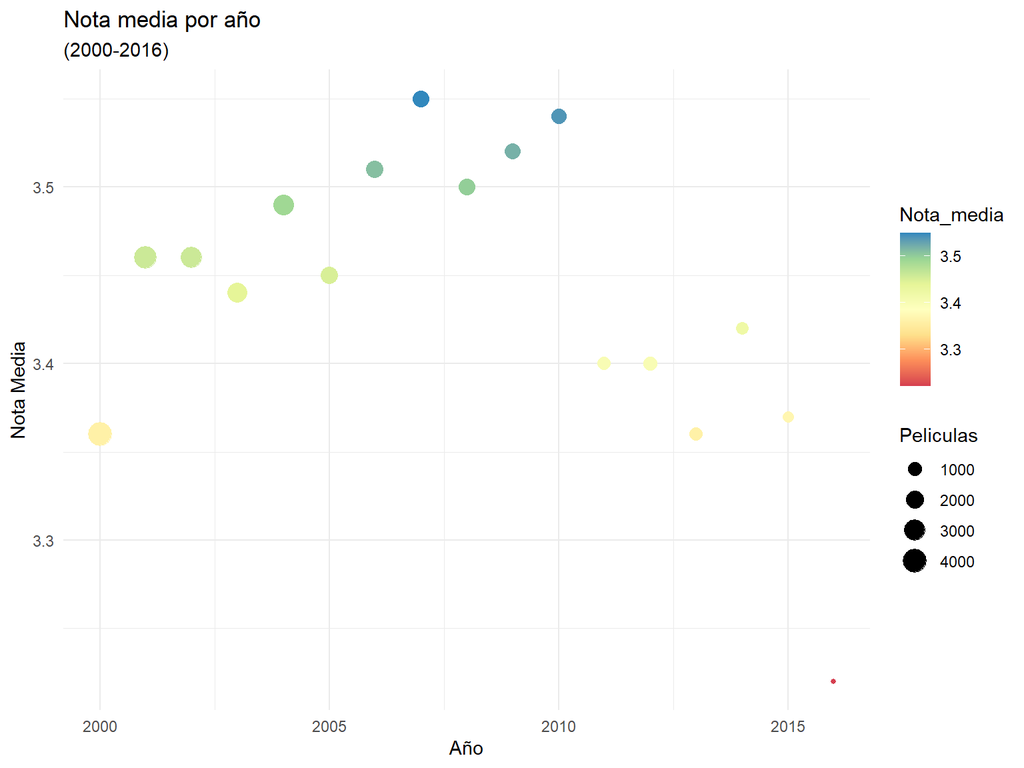

```r
ggplot(df_plot, aes(year, Nota_media, size=Peliculas, colour=Nota_media))+
  geom_point()+
  scale_color_distiller(palette='Spectral', direction = 1)+
  ylab('Nota Media')+
  xlab('Año')+
  labs(title = 'Nota media por año', subtitle = '(2000-2016)')+
  theme_minimal()
```